# ICY0006: Statistics and probabilty theory project

Markus Aas 192920IVSB

### Stage 1: Information about the dataset and distribution graphs.

My chosen dataset is about [Apartment prices in Sao Paulo](https://www.kaggle.com/felipecabueno/apartment-prices-in-sao-paulo-br-2020), which I got from the website [Kaggle](https://www.kaggle.com/).

The dataset has 7 variables in total, of which 6 are numerical and 1 is categorical. The categorical variable in our case is

- neighborhood name

and the numerical variables are

- area of the apartment in square meters
- number of bedrooms
- number of bathrooms
- number of suites (set of rooms, usually bedroom with its own bathroom)
- number of parking spaces
- final price of the apartment in thousands of reais (R$, Brazilian currency).

Here is an example of the 10 first rows of my dataset and basic information about the dataset:

```r
apartments_sp <- read.csv("C:/Users/aasma/Statistics/apartments_sp.csv")
head(apartments_sp, n=10)
```

|  | neighborhood | square_meters | bedrooms | bathrooms | suites | parking_spaces | final_price |
| --- | --- | --- | --- | --- | --- | --- | --- |
| 1 | bras | 57 | 2 | 1 | 0 | 1 | 385.185 |
| 2 | santa cecilia | 430 | 4 | 3 | 0 | 5 | 3200.000 |
| 3 | bras | 57 | 2 | 1 | 0 | 1 | 410.000 |
| 4 | santa cecilia | 250 | 4 | 3 | 0 | 2 | 1200.000 |
| 5 | consolacao | 177 | 3 | 3 | 0 | 1 | 1390.000 |
| 6 | santa cecilia | 126 | 3 | 2 | 0 | 1 | 795.000 |
| 7 | bela vista | 250 | 4 | 3 | 0 | 1 | 1300.000 |
| 8 | cerqueira cesar | 67 | 2 | 2 | 0 | 1 | 809.000 |
| 9 | cerqueira cesar | 380 | 4 | 2 | 0 | 4 | 3800.000 |
| 10 | bom retiro | 97 | 2 | 3 | 0 | 2 | 750.000 |

```r
str(apartments_sp)
```

```
'data.frame':   15703 obs. of  7 variables:
 $ neighborhood  : chr  "bras" "santa cecilia" "bras" "santa cecilia" ...
 $ square_meters : int  57 430 57 250 177 126 250 67 380 97 ...
 $ bedrooms      : int  2 4 2 4 3 3 4 2 4 2 ...
 $ bathrooms     : int  1 3 1 3 3 2 3 2 2 3 ...
 $ suites        : int  0 0 0 0 0 0 0 0 0 0 ...
 $ parking_spaces: int  1 5 1 2 1 1 1 1 4 2 ...
 $ final_price   : num  385 3200 410 1200 1390 ...
```

As we can see, we have 15703 different objects in this dataset.

The dataset has no missing values or errors.

The following histograms and frequency polygons give an approximate understanding of the variables in the dataset and showcase the frequency and values of those variables. In front of each histogram I have also given the range of the variable, because in histograms, when we have a certain value very few amount of times, it won’t be showcased on histogram very well.

```r
library(ggplot2)

range(apartments_sp$square_meters)
```

```
[1]  23 864
```

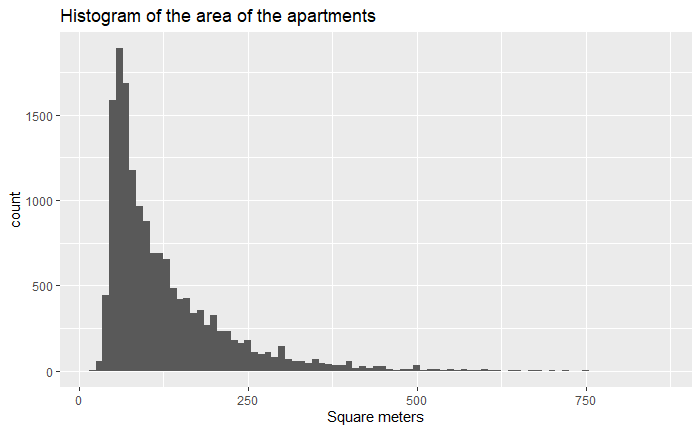

```r
ggplot(apartments_sp, aes(x=square_meters)) +
  geom_histogram(binwidth=10) +
  labs(title="Histogram of the area of the apartments", x="Square meters")
```

```r
range(apartments_sp$bedrooms)
```

```
[1] 1 8
```

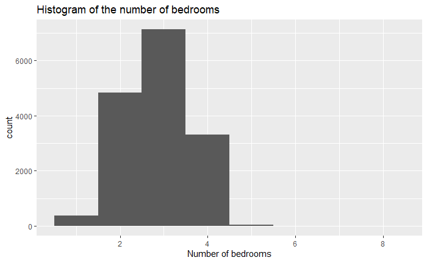

```r
ggplot(apartments_sp, aes(x=bedrooms)) +
  geom_histogram(binwidth=1) +
  labs(title="Histogram of the number of bedrooms", x="Number of bedrooms")
```

```r
range(apartments_sp$bathrooms)
```

```
[1]  1 10
```

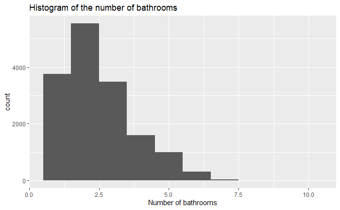

```r
ggplot(apartments_sp, aes(x=bathrooms)) +
  geom_histogram(binwidth=1) +
  labs(title="Histogram of the number of bathrooms", x="Number of bathrooms")
```

```r
range(apartments_sp$suites)
```

```
[1] 0 8
```

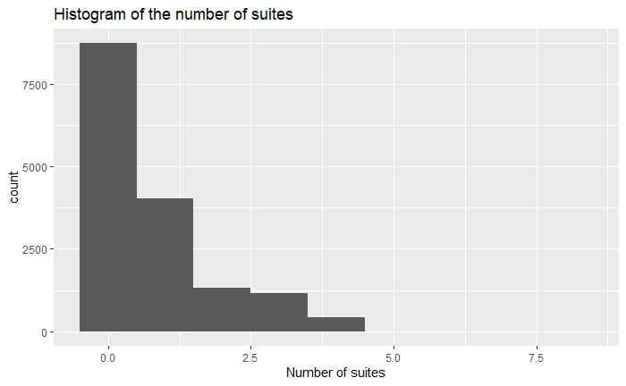

```r
ggplot(apartments_sp, aes(x=suites)) +
  geom_histogram(binwidth=1) +
  labs(title="Histogram of the number of suites", x="Number of suites")
```

```r
range(apartments_sp$parking_spaces)
```

```
[1]  1 10
```

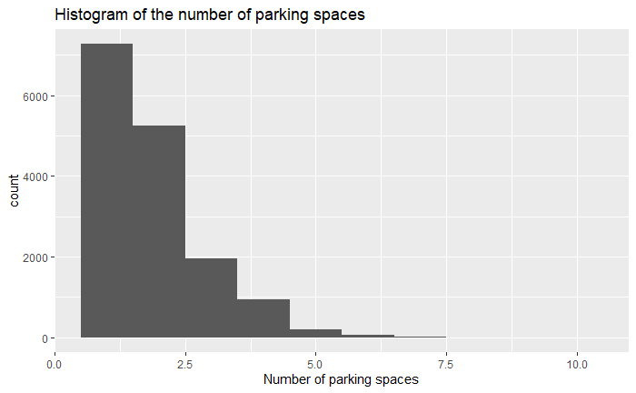

```r
ggplot(apartments_sp, aes(x=parking_spaces)) +
  geom_histogram(binwidth=1) +
  labs(title="Histogram of the number of parking spaces", x="Number of parking spaces")
```

```r
range(apartments_sp$final_price)
```

```
[1]   100 11000
```

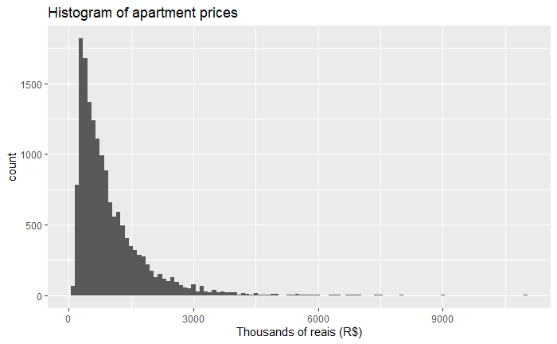

```r
ggplot(apartments_sp, aes(x=final_price)) +
  geom_histogram(binwidth=100) +
  labs(title="Histogram of apartment prices", x="Thousands of reais (R$)")
```

For constructing histograms I have used ggplot2 library and I have constructed a histogram of each numerical variable in the dataset. Histograms let a person immediately grasp the sizes of our variables and give a rough image of the dataset. Especially with more discrete variables like the number of bedrooms or the number of bathrooms, where there are few unique values, we can have a histogram bar for each unique value.

The first histogram shows how many apartments with how big of an area there are. From the histogram we can see, that the most frequent size of an apartment is approximately somewhere between 60 and 70 square meters and the sizes go over 800 square meters.

The second histogram shows how many apartments with how many bedrooms are there. From the range we can see that we have apartments with 1-8 bedrooms and 3 bedrooms in one apartment being the most common one.

The third histogram shows the number of bathrooms in apartments. We know that the number of bathrooms in one apartment ranges from 1-10 and we can see from the histogram that the most common value is 2.

The fourth histogram shows the number of suites in apartments. Suites range from 0-8 and the most common value is 0.

The fifth histogram shows the number of parking spaces for the apartment, which range from 1-10 and the most common one is 1.

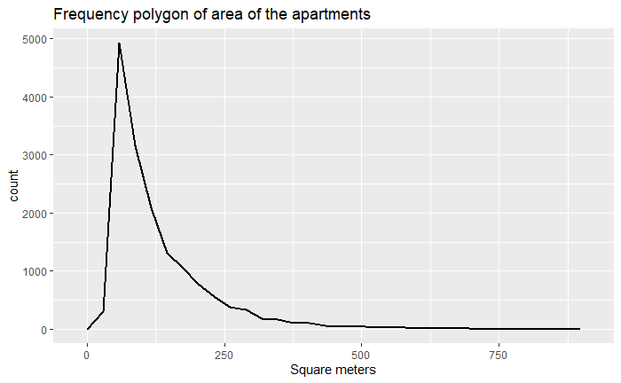

```r
library(ggplot2)

ggplot(apartments_sp, aes(x=square_meters)) +
  geom_freqpoly(size=0.8) +
  labs(title="Frequency polygon of area of the apartments", x="Square meters")
```

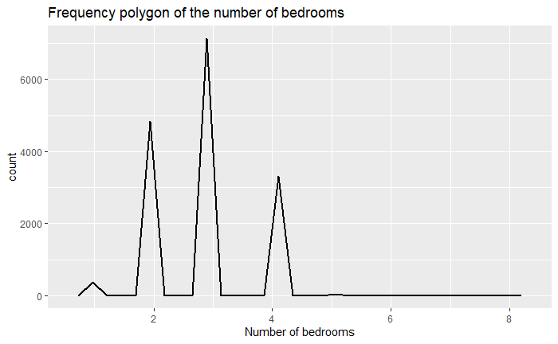

```r
ggplot(apartments_sp, aes(x=bedrooms)) +
  geom_freqpoly(size=0.8) +
  labs(title="Frequency polygon of the number of bedrooms", x="Number of bedrooms")
```

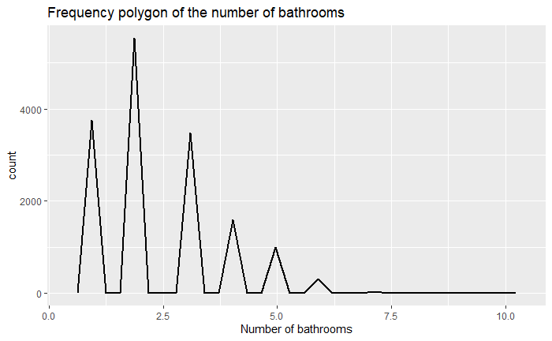

```r
ggplot(apartments_sp, aes(x=bathrooms)) +
  geom_freqpoly(size=0.8) +
  labs(title="Frequency polygon of the number of bathrooms", x="Number of bathrooms")
```

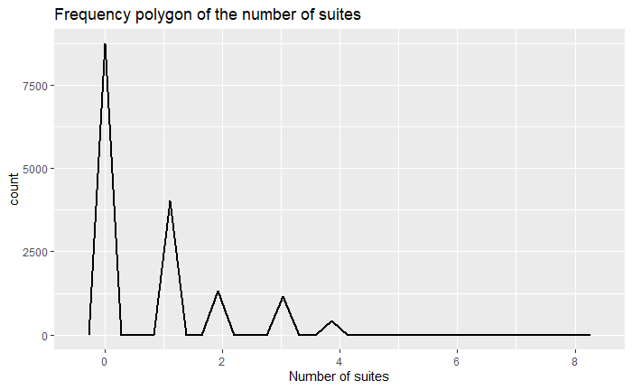

```r
ggplot(apartments_sp, aes(x=suites)) +
  geom_freqpoly(size=0.8) +
  labs(title="Frequency polygon of the number of suites", x="Number of suites")
```

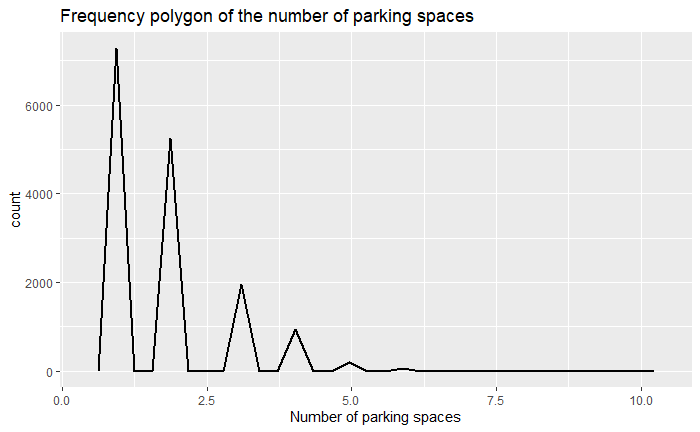

```r
ggplot(apartments_sp, aes(x=parking_spaces)) +
  geom_freqpoly(size=0.8) +
  labs(title="Frequency polygon of the number of parking spaces", x="Number of parking spaces")
```

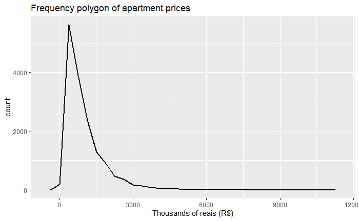

```r
ggplot(apartments_sp, aes(x=final_price)) +
  geom_freqpoly(size=0.8) +
  labs(title="Frequency polygon of apartment prices", x="Thousands of reais (R$)")
```

For frequency polygons I also used the ggplot2 library. In case of more discrete variables frequency polygons showcase the data similarly to histograms, but in case of continuous variables, frequency polygons do not rely on separate segments in the graphs like histograms do with bars, but showcase the variable with one line. Maybe frequency polygons are better for grasping how the dataset looks like faster, but histograms make it more accurately.

Frequency polygons show exactly the same data here, they just showcase it in a different way.

### Stage 2: Central tendency and variability

In stage 2 I have constructed two tables, one for central tendency measures and one for variability measures.

```r
library(knitr)
df <- data.frame(
  Variable = c("Square meters", "Bedrooms", "Bathrooms", "Suites", "Parking spaces", "Final price"),
  Mean = c(mean(apartments_sp$square_meters), mean(apartments_sp$bedrooms), mean(apartments_sp$bathrooms), mean(apartments_sp$suites),
           mean(apartments_sp$parking_spaces), mean(apartments_sp$final_price)),
  Median = c(median(apartments_sp$square_meters), median(apartments_sp$bedrooms), median(apartments_sp$bathrooms), median(apartments_sp$suites),
             median(apartments_sp$parking_spaces), median(apartments_sp$final_price)),
  Mode = c(names(table(apartments_sp$square_meters))[table(apartments_sp$square_meters)==max(table(apartments_sp$square_meters))],
           names(table(apartments_sp$bedrooms))[table(apartments_sp$bedrooms)==max(table(apartments_sp$bedrooms))],
           names(table(apartments_sp$bathrooms))[table(apartments_sp$bathrooms)==max(table(apartments_sp$bathrooms))],
           names(table(apartments_sp$suites))[table(apartments_sp$suites)==max(table(apartments_sp$suites))],
           names(table(apartments_sp$parking_spaces))[table(apartments_sp$parking_spaces)==max(table(apartments_sp$parking_spaces))],
           names(table(apartments_sp$final_price))[table(apartments_sp$final_price)==max(table(apartments_sp$final_price))]),
  Mean_trimmed_20_percent = c(mean(apartments_sp$square_meters, trim = 0.1), mean(apartments_sp$bedrooms, trim = 0.1),
                              mean(apartments_sp$bathrooms, trim = 0.1), mean(apartments_sp$suites, trim = 0.1),
                              mean(apartments_sp$parking_spaces, trim = 0.1), mean(apartments_sp$final_price, trim = 0.1))
)
kable(df, caption="Central tendency table")
```

Central tendency table

| Variable | Mean | Median | Mode | Mean_trimmed_20_percent |
| --- | --- | --- | --- | --- |
| Square meters | 128.0623448 | 96 | 70 | 110.8167635 |
| Bedrooms | 2.8606636 | 3 | 3 | 2.8512298 |
| Bathrooms | 2.4670445 | 2 | 2 | 2.3199873 |
| Suites | 0.7633573 | 0 | 0 | 0.5427844 |
| Parking spaces | 1.8448704 | 2 | 1 | 1.6753960 |
| Final price | 995.7737355 | 745 | 1200 | 844.7089073 |

In central tendency table I have four variables

- mean
- median
- mode
- mean trimmed 20%

From this table we can see, what are the average values in our variables (mean), the middle values (median), the most often occurring values (mode) and also averages, when 10% from both bottom and top is trimmed off (mean trimmed 20%).

I had decided to add the mean trimmed 20%, because some variables like square meters and final price can have some outliers, which can affect the mean maybe too much. After trimming 10% from both top and bottom of the variables we can see a decrease in the mean of square meters and final price, which is not that big of change, taking account their range, but still a change worth noting down. We can also see a quite significant change in mean in suites after trimming it, indicating the suites variable has outliers in the top end. When see the histogram and range of suites, we can see that we very small amount of suites in the range 5-8, which even doesn’t appear on the histogram and that is the reason, why the trimmed mean is so much smaller than the normal mean.

```r
library(knitr)
df1 <- data.frame(
   Variable = c("Square meters", "Bedrooms", "Bathrooms", "Suites", "Parking spaces", "Final price"),
   Range = c(max(apartments_sp$square_meters) - min(apartments_sp$square_meters), max(apartments_sp$bedrooms) - min(apartments_sp$bedrooms),
             max(apartments_sp$bathrooms) - min(apartments_sp$bathrooms), max(apartments_sp$suites) - min(apartments_sp$suites),
             max(apartments_sp$parking_spaces) - min(apartments_sp$parking_spaces), max(apartments_sp$final_price) - min(apartments_sp$final_price)),
   Interquartile_range = c(IQR(apartments_sp$square_meters), IQR(apartments_sp$bedrooms), IQR(apartments_sp$bathrooms),
                           IQR(apartments_sp$suites), IQR(apartments_sp$parking_spaces), IQR(apartments_sp$final_price)),
   Variance = c(var(apartments_sp$square_meters), var(apartments_sp$bedrooms), var(apartments_sp$bathrooms), var(apartments_sp$suites),
                var(apartments_sp$parking_spaces), "-"),
   Standard_deviation = c(sd(apartments_sp$square_meters), sd(apartments_sp$bedrooms), sd(apartments_sp$bathrooms),
                          sd(apartments_sp$suites), sd(apartments_sp$parking_spaces), sd(apartments_sp$final_price))
)
kable(df1, caption="Variability table")
```

Variability table

| Variable | Range | Interquartile_range | Variance | Standard_deviation |
| --- | --- | --- | --- | --- |
| Square meters | 841 | 95 | 8718.88892908326 | 93.3749909 |
| Bedrooms | 7 | 1 | 0.613624499148322 | 0.7833419 |
| Bathrooms | 9 | 1 | 1.60519013730002 | 1.2669610 |
| Suites | 8 | 1 | 1.14448069049013 | 1.0698040 |
| Parking spaces | 9 | 1 | 1.02981176355102 | 1.0147964 |
| Final price | 10900 | 842 | - | 858.8784531 |

In my variability table I also have four variables, which are

- range
- interquartile range
- standard deviation
- variance

I have omitted in this table the variance of final price, because it is a very big number, which messes up the values of the whole variance column. The variance of final price is the following:

```r
var(apartments_sp$final_price)
```

```
[1] 737672.2
```

From the values in the table we can see the range of values in a variable, which I also showed with the histograms, the range of the middle 50% of the values in a distribution (interquartile range), the average squared difference of values from the mean (variance) and standard deviation from the mean, which is square root of the variance.

From the results here we can see, that interquartile range is abnormally smaller than range. That implies, that in all variables the values in either top end, bottom end or in both take up a much smaller amount of the total number of values in variable than rest of the values. That could also indicate the presence of potential outliers. Similar deduction can be made with standard deviation in square meters and final price, where standard deviation shows, that the values can deviate from the mean quite a bit.

### Stage 3: Linear relationships and linear regression

To see whether I have linear relationships in my dataset, I have constructed a correlation matrix table, where we can see the correlation between all the numerical variables.

```r
library(knitr)

df2 <- apartments_sp[ , 2:7]

kable(cor(df2))
```

|  | square_meters | bedrooms | bathrooms | suites | parking_spaces | final_price |
| --- | --- | --- | --- | --- | --- | --- |
| square_meters | 1.0000000 | 0.6476059 | 0.6959544 | 0.5875700 | 0.6940029 | 0.7944946 |
| bedrooms | 0.6476059 | 1.0000000 | 0.6596583 | 0.5107088 | 0.6228615 | 0.5650996 |
| bathrooms | 0.6959544 | 0.6596583 | 1.0000000 | 0.8042544 | 0.7203087 | 0.6606504 |
| suites | 0.5875700 | 0.5107088 | 0.8042544 | 1.0000000 | 0.6619812 | 0.5671287 |
| parking_spaces | 0.6940029 | 0.6228615 | 0.7203087 | 0.6619812 | 1.0000000 | 0.6728421 |
| final_price | 0.7944946 | 0.5650996 | 0.6606504 | 0.5671287 | 0.6728421 | 1.0000000 |

```r
NA
```

From the correlation matrix we can see that every variable has a linear relationship with other variables. The strength of the correlations ranges from moderate to strong in my case, with moderate meaning the correlation coefficient is between 0,5 and 0,75 and strong meaning the coefficient is between 0,75 and 0,9.

I chose the top 5 pairs of variables, that have the highest correlation coefficients to visualize them using scatter plots. I also use here the ggplot2 library and in case of discrete variables like number of bedrooms and so on I used geom_jitter instead of geom_point, so that I would have each separate point in my scatter plots represented. Otherwise I would have points on top of each other forming lines and they wouldn’t give a visually good representation of the data in my dataset.

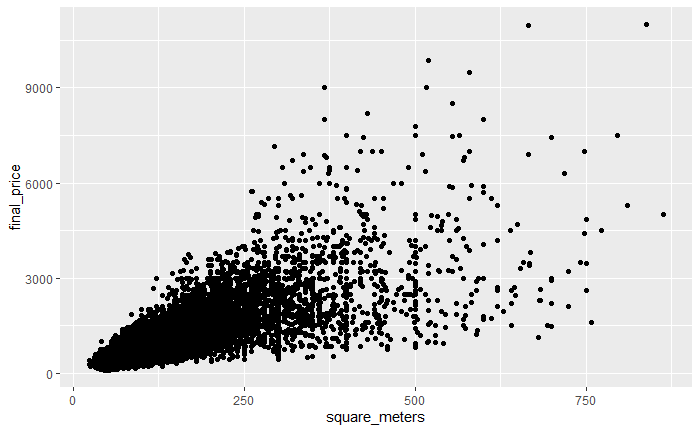

```r
library(ggplot2)

ggplot(apartments_sp, aes(x=square_meters, y=final_price)) +
  geom_point()
```

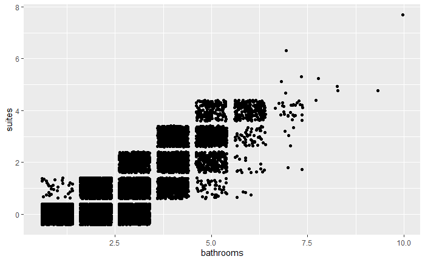

```r
ggplot(apartments_sp, aes(x=bathrooms, y=suites)) +
  geom_jitter()
```

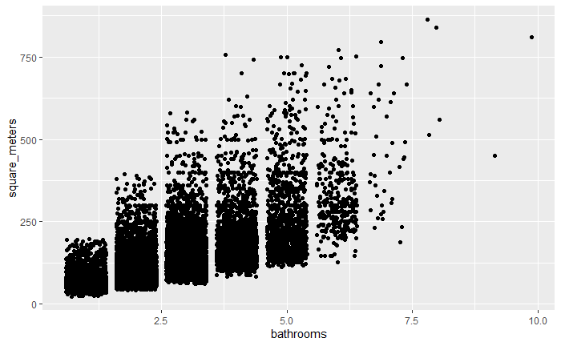

```r
ggplot(apartments_sp, aes(x=bathrooms, y=square_meters)) +
  geom_jitter()
```

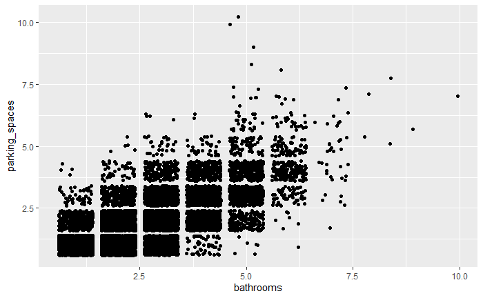

```r
ggplot(apartments_sp, aes(x=bathrooms, y=parking_spaces)) +
  geom_jitter()
```

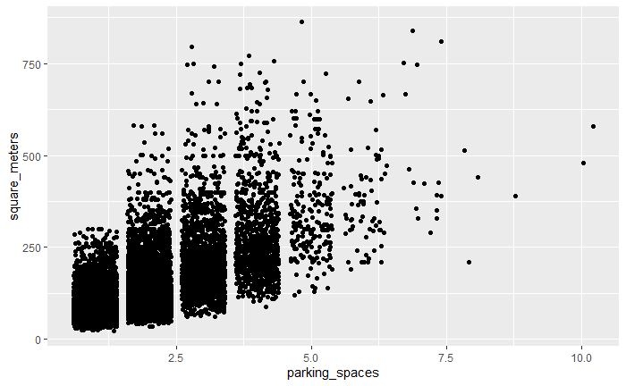

```r
ggplot(apartments_sp, aes(x=parking_spaces, y=square_meters)) +
  geom_jitter()
```

```r
NA
NA
```

As a dependent variable for linear regression I chose final price, because although all the variables have linear relationships with each other, only square meters and final price are continuous variables and final price would be a more logical choice out of those two as a dependent variable in my opinion. And as an independent variable for the linear regression I naturally chose square meters, because it is the other continuous variable and it should therefore give the best results.

```r
library(ggplot2)

lmMod <- lm(apartments_sp$final_price ~ apartments_sp$square_meters)
lmMod
```

```
Call:
lm(formula = apartments_sp$final_price ~ apartments_sp$square_meters)

Coefficients:
                (Intercept)  apartments_sp$square_meters
                     59.908                        7.308
```

Here we have applied the linear regression formula and gotten our coefficients to construct a linear regression equation which is:

**final_price = 59.908 + 7.308 * square_meters**.

Next we construct a scatter plot, which we also did before, but now with a line showcasing the linear relationship between those two variables visually.

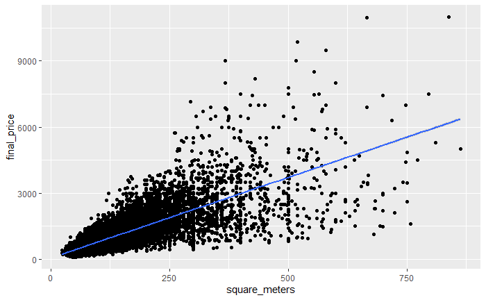

```r
ggplot(apartments_sp, aes(x=square_meters, y=final_price)) +
  geom_point() +
  geom_smooth(method=lm)
```

We can see, that our variables have a solid linear relationship and you could say that we have quite few outliers, but taking into account the sheer amount of variables I have in my dataset, I didn’t find it necessary to remove them as I would believe there wouldn’t be any drastic changes.

### Stage 4:

For stage 4 I chose the lottery EuroMillions. EuroMillions is an European lottery, where players have to choose 5 correct main numbers from the range 1 to 50 and 2 correct extra lucky star numbers from the range 1 to 12 in order to win the jackpot prize.

To compute the probabilities to win the largest prize, we are going to use the following formula on both the main numbers and lucky star numbers:

**n! / (r! * (n - r)!)**

where n is the total number of possible numbers and r is the number of numbers chosen.

For information I am not going to directly calculate the whole fraction of the probability of winning, because then we would get abnormally small numbers, which would not be well presented in RStudio. Instead I am going to calculate just the denominator so that we would have a nice value.

So the computation in our case for main prize (5 main numbers guessed correctly and 2 lucky star numbers guessed correctly) would be as following:

```r
main_numbers <- factorial(50) / (factorial(5) * factorial(50 - 5))
lucky_stars <- factorial(12) / (factorial(2) * factorial(12 - 2))

main_numbers * lucky_stars
```

```
[1] 139838160
```

We computed the probabilities of choosing all the main numbers correctly and all the lucky star numbers correctly first separately and then we multiplies them together. And as a result we know that we have **1 in 139 838 160** chance of winning the main prize.

For odds for smaller winnings we have to use a more complicated formula:

**(r! / (k! * (r - k)!)) * ((n-r)! / ((n - r) - (r - k))! * (r - k)!)**

where n and r are the same as in the previous formula and k is the numbers chosen correctly.

So now that we have all the necessary formulas, we can compute the rest of the winning chances.

For simplicity I am not going to write out the full formulas if computations are easy. It would be messy in RStudio and it wouldn’t be worth it. I also am not going to redo calculations, that I have already done. So the rest of the winning chances formulas are as follows.

The computation for 5 main numbers and 1 lucky star number guessed:

```r
one_lucky_star <- lucky_stars / (2 * (factorial(10) / factorial(9)))

main_numbers * one_lucky_star
```

```
[1] 6991908
```

The probability is **1 in 6 991 908**.

For 5 main numbers and 0 lucky star numbers:

```r
zero_lucky_starts <- lucky_stars / (factorial(10) / (factorial(8) * 2))

main_numbers * zero_lucky_starts
```

```
[1] 3107515
```

The probability is **1 in 3 107 515**.

For 4 main numbers and 2 lucky star numbers:

```r
four_main_numbers <- main_numbers / ((factorial(5) / factorial(4)) * (factorial(45) / factorial(44)))
four_main_numbers * lucky_stars
```

```
[1] 621502.9
```

The probability is **1 in 621 503**.

For 4 main numbers and 1 lucky star number:

```r
four_main_numbers * one_lucky_star
```

```
[1] 31075.15
```

The probability is **1 in 31 075**.

For 3 main numbers and 2 lucky star numbers:

```r
three_main_numbers <- main_numbers / ((factorial(5) / 12) * (factorial(45) / (factorial(43) * 2)))
three_main_numbers * lucky_stars
```

```
[1] 14125.07
```

The probability is **1 in 14 125**.

For 4 main numbers and 0 lucky star numbers:

```r
four_main_numbers * zero_lucky_starts
```

```
[1] 13811.18
```

The probability is **1 in 13 811**.

For 2 main number and 2 lucky star numbers:

```r
two_main_numbers <- main_numbers / ((factorial(5) / 12) * (factorial(45) / (factorial(42) * 6)))
two_main_numbers * lucky_stars
```

```
[1] 985.4698
```

The probability is **1 in 985**.

For 3 main numbers and 1 lucky star number:

```r
three_main_numbers * one_lucky_star
```

```
[1] 706.2533
```

The probability is **1 in 706**.

For 3 main numbers and 0 lucky star numbers:

```r
three_main_numbers * zero_lucky_starts
```

```
[1] 313.8904
```

The probability is **1 in 314**.

For 1 main number and 2 lucky star numbers:

```r
one_main_number <- main_numbers / ((factorial(5) / 24) * (factorial(45) / (factorial(41) * 24)))
one_main_number * lucky_stars
```

```
[1] 187.7085
```

The probability is **1 in 188**.

For 2 main numbers and 1 lucky star number:

```r
two_main_numbers * one_lucky_star
```

```
[1] 49.27349
```

The probability is **1 in 49**.

For 2 main numbers and 0 lucky star numbers:

```r
two_main_numbers * zero_lucky_starts
```

```
[1] 21.89933
```

The probability is **1 in 22**.

So there we have all probabilities of winning for each main number and lucky star number combination, that are eligible for a prize.

[EuroMillions wikipedia](https://en.wikipedia.org/wiki/EuroMillions)

[Formula source](https://www.wikihow.com/Calculate-Lotto-Odds)

### Stage 5:

In stage 5 first we are going to split the dataset into training and testing sets, with the training set being 80% of the whole dataset and testing set being 20%.

```r
dt <- apartments_sp[ , 2:7]
smp_siz = floor(0.80*nrow(dt))
set.seed(123)
train_ind = sample(seq_len(nrow(dt)), size = smp_siz)
train = dt[train_ind,]
test = dt[-train_ind,]
nrow(train)
```

```
[1] 12562
```

```r
nrow(test)
```

```
[1] 3141
```

Here we can see, that now we have a training set with 12562 objects and a testing set with 3141 objects.

Now we are going to get the linear regression model from the training set:

```r
library(knitr)

kable(cor(train))
```

|  | square_meters | bedrooms | bathrooms | suites | parking_spaces | final_price |
| --- | --- | --- | --- | --- | --- | --- |
| square_meters | 1.0000000 | 0.6499308 | 0.6951459 | 0.5854887 | 0.6968252 | 0.7917008 |
| bedrooms | 0.6499308 | 1.0000000 | 0.6611435 | 0.5128573 | 0.6239703 | 0.5667969 |
| bathrooms | 0.6951459 | 0.6611435 | 1.0000000 | 0.8048765 | 0.7220201 | 0.6595900 |
| suites | 0.5854887 | 0.5128573 | 0.8048765 | 1.0000000 | 0.6642698 | 0.5684205 |
| parking_spaces | 0.6968252 | 0.6239703 | 0.7220201 | 0.6642698 | 1.0000000 | 0.6737874 |
| final_price | 0.7917008 | 0.5667969 | 0.6595900 | 0.5684205 | 0.6737874 | 1.0000000 |

Here we have again a table for correlation matrix, but this time it is only for the training set.

Now we construct a linear regression equation using only the data in the training set. I have also included the scatter plot of the training set, but it visually looks basically the same.

```r
library(ggplot2)

lmMod <- lm(train$final_price ~ train$square_meters)
lmMod
```

```
Call:
lm(formula = train$final_price ~ train$square_meters)

Coefficients:
        (Intercept)  train$square_meters
             62.081                7.276
```

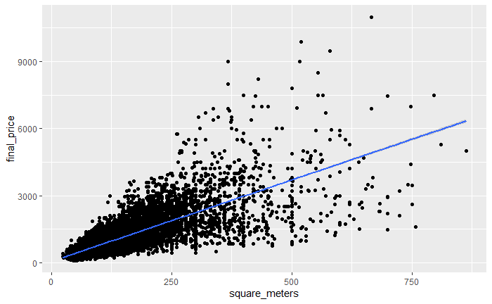

```r
ggplot(train, aes(x=square_meters, y=final_price)) +
  geom_point() +
  geom_smooth(method=lm)
```

Linear regression equation for our training set is:

**final_price = 62.081 + 7.276 * square_meters**

Now we need to use that linear regression equation on the testing set and see how accurate it is. In order to do that I have made another dataset, where I have all final prices of the apartments, that I got using the linear regression equation. Then I am going to compare it to the testing set final prices and see their differences. For that I have used the mean absolute percentage error (MAPE), Root-mean-square error (RMSE) and Mean absolute error (MAE). To calculate those I have used MLmetrics library.

```r
library(MLmetrics)

test_final_price <- c()

i <- 1

for (val in test$square_meters) {
  test_final_price[i] <- 62.081 + 7.276 * val
  i <- i + 1
}

test_training <- data.frame(test_final_price)

MAPE(test_training$test_final_price, test$final_price)
```

```
[1] 0.3652429
```

```r
RMSE(test$final_price, test_training$test_final_price)
```

```
[1] 520.0346
```

```r
MAE(test_training$test_final_price, test$final_price)
```

```
[1] 307.1701
```

From MAPE result, which is 0.36 or 36%, we can see, that the error percentage is quite big. 36% is a noteworthy amount and should definitely be taken into account, when using the linear regression equation to get some values which in our case are apartment prices. You can use the linear regression equation to get a rough estimation for an apartment price, but you definitely shouldn’t rely on it too much.

Seeing the RMSE result, which is 520, we can also see that the actual prices can deviate quite a bit from the calculated ones and you shouldn’t trust the calculated values that much.

The same goes for MAE result, which is 307. In conclusion I would say that this linear regression equation could be used to get a very rough estimate of the apartment prices, but you definitely shouldn’t trust those result very much as they could deviate from the real price quite a bit. They do give a rough idea of how much apartments with a certain area could cost.